# PersonalActivityAnalysis

Gonzalo Bailador del Pozo

25 de abril de 2017

## Loading the data

First of all, we have to load the data from the csv file:

```r
activity<-read.csv('activity.csv')
```

We convert the field that contains the date in date format:

```r
activity$date<-as.Date(activity$date,"%Y-%m-%d")
activity$interval<-as.factor(activity$interval)
```

## Number of steps taken per day

We calculate the total number of steps taken per day and we represent them using a histogram

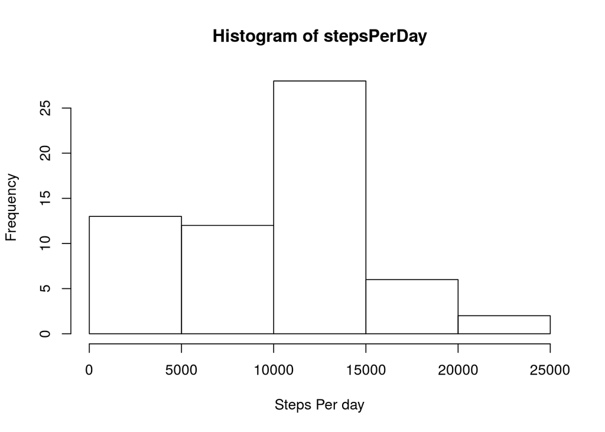

```r
stepsPerDay<-sapply(split(activity,activity$date),function (x) sum(x$steps,na.rm=TRUE))
hist(stepsPerDay,xlab="Steps Per day")
```

The mean of the total number of steps taken per day is:

```r
mean(stepsPerDay)
```

```
## [1] 9354.23
```

The median of the total number of steps taken per day is:

```r
median(stepsPerDay)
```

```
## [1] 10395
```

## What is the average daily pattern activity?

We make a plot of the 5-minute interval and average number of steps taken averaged accross all days.

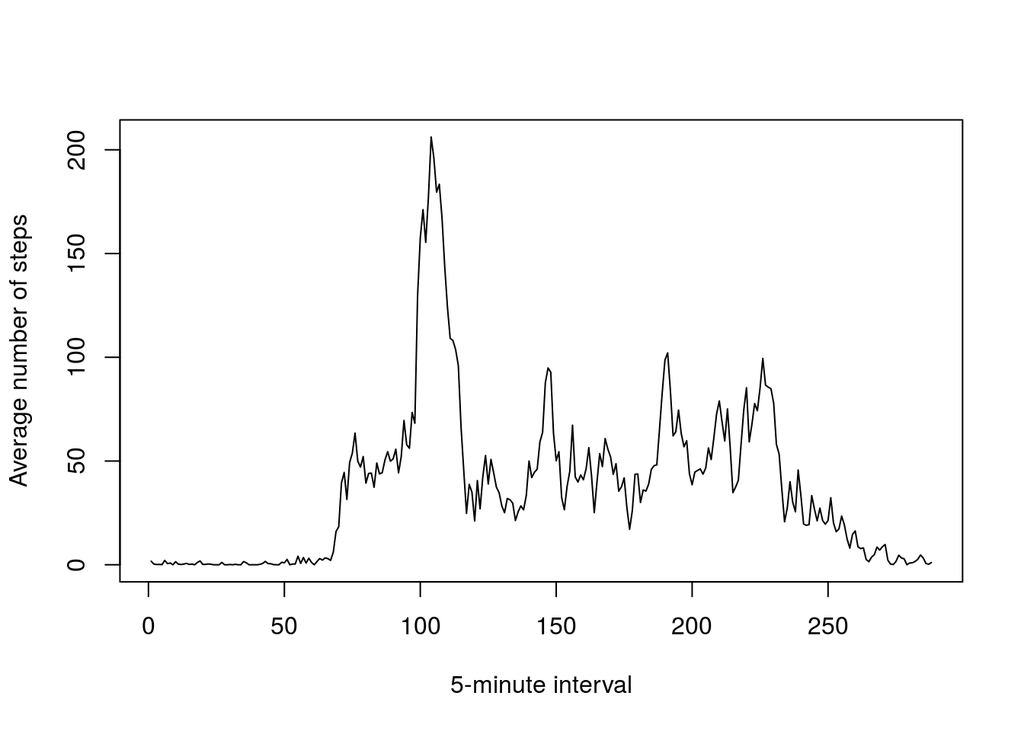

```r
averageStepsPerInterval<-sapply(split(activity,activity$interval),function (x) mean(x$steps,na.rm=TRUE))
plot(averageStepsPerInterval,type='l',xlab='5-minute interval',ylab='Average number of steps')
```

The maximum average number of steps is

```r
max(averageStepsPerInterval)
```

```
## [1] 206.1698
```

which corresponds to the following 5-minute interval:

```r
which.max(averageStepsPerInterval)
```

```
## 835
## 104
```

## Imputing missing values

There are no missing values for the columns date and interval but there are missing values in steps column. The number of missing values is:

```r
sum(is.na(activity))
```

```
## [1] 2304
```

In order to filling in all of the missing values in the dataset, we will replace them with the mean for that interval across all days because there are days that all the data are missing values. These averages have been calculated previously.

```r
missingRows<-which(is.na(activity$steps))
replacements<-averageStepsPerInterval[activity$interval[missingRows]]
activityWithoutNA<-activity
activityWithoutNA$steps<-replace(activity$steps,missingRows,replacements)
```

We recalculate the histogram after replacing the missing values.

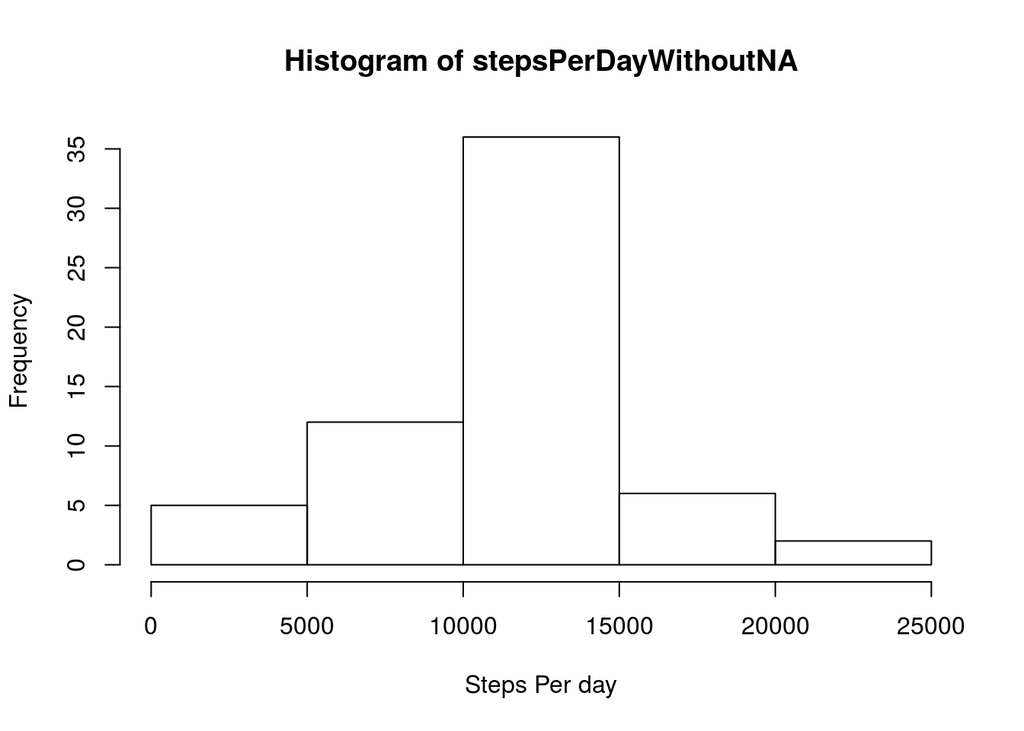

```r
stepsPerDayWithoutNA<-sapply(split(activityWithoutNA,activityWithoutNA$date),function (x) sum(x$steps,na.rm=TRUE))
hist(stepsPerDayWithoutNA,xlab="Steps Per day")
```

And we also recalculate the mean and median for the new dataset

The mean of the total number of steps taken per day is:

```r
mean(stepsPerDayWithoutNA)
```

```
## [1] 10766.19
```

The median of the total number of steps taken per day is:

```r
median(stepsPerDayWithoutNA)
```

```
## [1] 10766.19
```

As it can be seen after removing the missing values, the mean and median are the same which is a good point since in the previous analysis without replacing the missing values, they were quite different.

## Are there differences in activity patterns between weekdays and weekends

First of all, we have to create a new factor variable that indicates if a given day is weekday or weekend day.

```r
activityWithoutNA$weekday<-weekdays(activityWithoutNA$date)
activityWithoutNA$typeofday<-factor(activityWithoutNA$weekday=="sábado" | activityWithoutNA$weekday=="domingo",levels=c(TRUE,FALSE),labels=c("weekend","weekday"))
```

We make two plots of the 5-minute interval and average number of steps taken averaged accross weekdays and weekend,separately.

[figure not shown]

```r
activityWeekday<-activityWithoutNA[activityWithoutNA$typeofday=="weekday",]
activityWeekend<-activityWithoutNA[activityWithoutNA$typeofday=="weekend",]

averageStepsPerIntervalWeekday<-sapply(split(activityWeekday,activityWeekday$interval),function (x) mean(x$steps,na.rm=TRUE))

averageStepsPerIntervalWeekend<-sapply(split(activityWeekend,activityWeekend$interval),function (x) mean(x$steps,na.rm=TRUE))
par(mfrow=c(2,1))
plot(averageStepsPerIntervalWeekday,type='l',xlab='5-minute interval',ylab='Average number of steps for weekdays')
plot(averageStepsPerIntervalWeekend,type='l',xlab='5-minute interval',ylab='Average number of steps for weekdays')
```